# FA

Anh Khoa Vo

November 9, 2017

We have found that Albumin at week 4 is predictive of outcome - motor scores by week 52. However, I was wondering if a set of observed variables would have a better chance of predicting outcome than just one single variable.

Exploratory Factor Analysis (EFA) has been used to explore the possible underlying factor structure of a set of observed variables without imposing a preconcieved structure on the outcome. By performing EFA, the underlying factor structure is identified.

First, I upload the data set, and scale every variable in the dataset to reduce large variance between variable. I also remove two variables in the dataset since these two have the most missing data. (This led to several problems for my EFA later on)

To identify the correct number of factors to pick for analysis, we can visualize it using scree plot.

```r
library(psych)
scree <- fa.parallel(cfa1_week0[-1:-3], fm = "ml", fa = "fa")
```

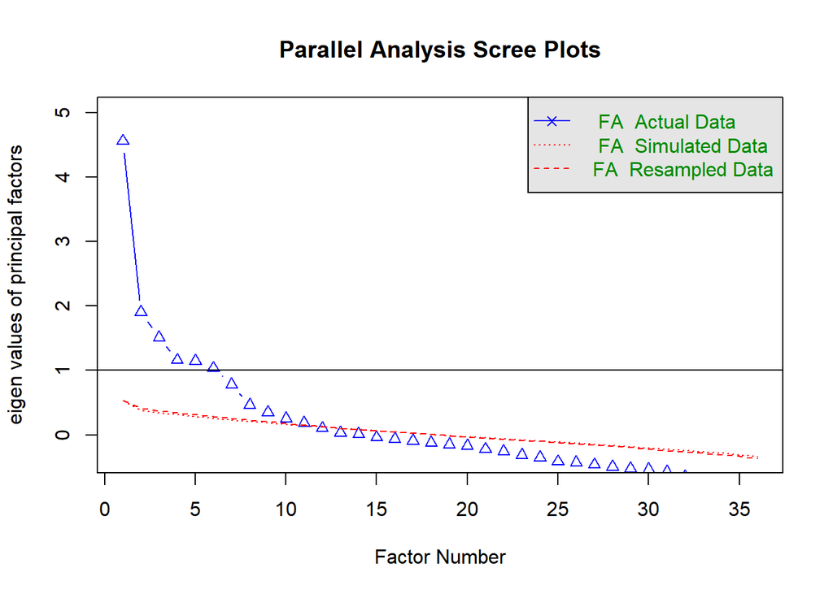

```
## Parallel analysis suggests that the number of factors =  11  and the number of components =  NA
```

```r
scree
```

```
## Call: fa.parallel(x = cfa1_week0[-1:-3], fm = "ml", fa = "fa")
## Parallel analysis suggests that the number of factors =  11  and the number of components =  NA
##
##  Eigen Values of
##
##  eigen values of factors
##  [1]  4.56  1.91  1.51  1.16  1.14  1.04  0.78  0.46  0.35  0.25  0.18
## [12]  0.10  0.03  0.01 -0.04 -0.07 -0.09 -0.12 -0.15 -0.17 -0.22 -0.26
## [23] -0.31 -0.35 -0.42 -0.43 -0.46 -0.50 -0.53 -0.54 -0.57 -0.65 -0.79
## [34] -0.82 -0.89 -0.98
##
##  eigen values of simulated factors
##  [1]  0.54  0.38  0.34  0.31  0.28  0.26  0.23  0.21  0.19  0.16  0.14
## [12]  0.12  0.10  0.08  0.06  0.05  0.03  0.01 -0.01 -0.03 -0.05 -0.06
## [23] -0.08 -0.10 -0.11 -0.13 -0.15 -0.17 -0.19 -0.20 -0.22 -0.24 -0.26
## [34] -0.29 -0.31 -0.34
##
##  eigen values of components
##  [1] 5.02 2.88 2.49 2.14 2.07 1.93 1.44 1.38 1.29 1.19 1.15 1.03 1.00 0.96
## [15] 0.93 0.89 0.85 0.82 0.75 0.72 0.65 0.60 0.55 0.51 0.49 0.45 0.43 0.39
## [29] 0.36 0.20 0.18 0.14 0.08 0.00 0.00 0.00
##
##  eigen values of simulated components
## [1] NA
```

To visualize the number of factors and the variables inside each factor

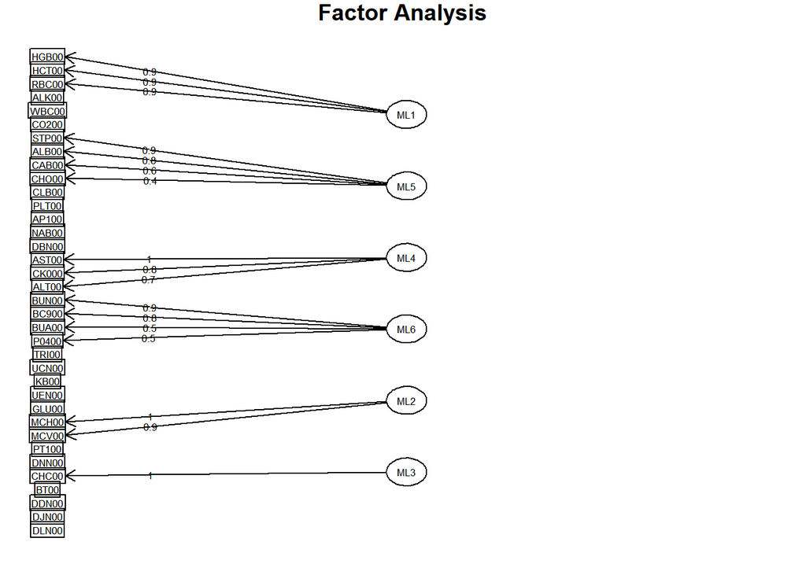

```r
fa <- fa(cfa1_week0[-1:-3], nfactors=6, rotate="varimax", fm="ml")
fa.diagram(fa)
```

```r
library(lavaan)
model0 <- 'Factor 1 =~ HGB00 + HCT00 + RBC00
           Factor 2 =~ STP00 + ALB00 + CAB00 + CHO00
           Factor 3 =~ AST00 + CK000 + ALT00
           Factor 4 =~ BUN00 + BC900 + BUA00 + P0400
           Factor 5 =~ MCV00 + MCH00
           TLAMS52 ~ Factor 1 + Factor 2 + Factor 3 + Factor 4 + Factor 5 + CHC00'

f1_week0 <- sem(model0, data = cfa1_week0, std.lv=TRUE, na.action=na.omit, missing = "fiml")
summary(f1_week0, standardized = TRUE, fit.measures = TRUE)
```

```
## lavaan (0.5-23.1097) converged normally after 195 iterations
##
##                                                   Used       Total
##   Number of observations                           786         797
##
##   Number of missing patterns                        12
##
##   Estimator                                         ML
##   Minimum Function Test Statistic             7451.224
##   Degrees of freedom                               121
##   P-value (Chi-square)                           0.000
##
## Model test baseline model:
##
##   Minimum Function Test Statistic            16576.958
##   Degrees of freedom                               153
##   P-value                                        0.000
##
## User model versus baseline model:
##
##   Comparative Fit Index (CFI)                    0.554
##   Tucker-Lewis Index (TLI)                       0.436
##
## Loglikelihood and Information Criteria:
##
##   Loglikelihood user model (H0)             -14261.698
##   Loglikelihood unrestricted model (H1)     -10536.086
##
##   Number of free parameters                         66
##   Akaike (AIC)                               28655.396
##   Bayesian (BIC)                             28963.416
##   Sample-size adjusted Bayesian (BIC)        28753.832
##
## Root Mean Square Error of Approximation:
##
##   RMSEA                                          0.278
##   90 Percent Confidence Interval          0.272  0.283
##   P-value RMSEA <= 0.05                          0.000
##
## Standardized Root Mean Square Residual:
```

[output cut: 93 more lines]

```
##    .AST00            -0.340    0.049   -6.973    0.000   -0.340   -0.341
##    .CK000             0.498    0.032   15.783    0.000    0.498    0.482
##    .ALT00             0.626    0.034   18.265    0.000    0.626    0.628
##    .BUN00             0.295    0.030    9.984    0.000    0.295    0.296
##    .BC900             0.284    0.030    9.534    0.000    0.284    0.284
##    .BUA00             0.701    0.040   17.670    0.000    0.701    0.702
##    .P0400             0.710    0.040   17.836    0.000    0.710    0.711
##    .MCV00            -4.635    7.725   -0.600    0.549   -4.635   -4.640
##    .MCH00             0.865    0.189    4.588    0.000    0.865    0.866
##    .TLAMS52           0.948    0.054   17.703    0.000    0.948    0.949
##     Factor1           1.000                               1.000    1.000
##     Factor2           1.000                               1.000    1.000
##     Factor3           1.000                               1.000    1.000
##     Factor4           1.000                               1.000    1.000
##     Factor5           1.000                               1.000    1.000
```

The output comes out with a summary table. However, I am not quite sure what the internal statistics behind this function. Therefore, I’d prefer to analyse the data by mysel. Anyway, this is the graph to visualize the previous summary table:

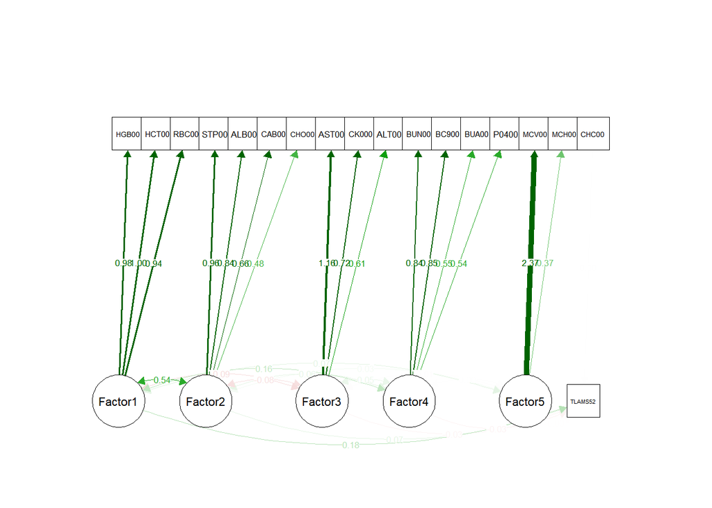

```r
library(semPlot)
semPaths(f1_week0,"std", whatLabels="std", intercepts=FALSE, style="lisrel", residuals = FALSE,
         nCharNodes=0,
         nCharEdges=0,
         curveAdjacent = TRUE,title=TRUE, layout="tree2",curvePivot=FALSE)
```

Now, to run the analysis, I need to compute the estimated values for latent variables!!!!

And now, In order to see which factor is predictive of outcome, I run a simple linear regression:

```r
factor_lm <- function(x) {
  f1 <- summary(lm(TLAMS52 ~ Factor1, data = x))
  f2 <- summary(lm(TLAMS52 ~ Factor2, data = x))
  f3 <- summary(lm(TLAMS52 ~ Factor3, data = x))
  f4 <- summary(lm(TLAMS52 ~ Factor4, data = x))
  f5 <- summary(lm(TLAMS52 ~ Factor5, data = x))
  f6 <- summary(lm(TLAMS52 ~ CHC00, data=x))
  return(list(f1,f2,f3,f4,f5,f6))
}

factor_lm(cfa2_week0)
```

```
## [[1]]
##
## Call:
## lm(formula = TLAMS52 ~ Factor1, data = x)
##
## Residuals:
##     Min      1Q  Median      3Q     Max
## -1.4786 -0.6842 -0.4706  0.9040  2.1931
##
## Coefficients:
##             Estimate Std. Error t value Pr(>|t|)
## (Intercept) 0.008698   0.038820   0.224    0.823
## Factor1     0.226753   0.040343   5.621 2.85e-08 ***
## ---
## Signif. codes:  0 '***' 0.001 '**' 0.01 '*' 0.05 '.' 0.1 ' ' 1
##
## Residual standard error: 0.9767 on 632 degrees of freedom
##   (163 observations deleted due to missingness)
## Multiple R-squared:  0.04761,    Adjusted R-squared:  0.0461
## F-statistic: 31.59 on 1 and 632 DF,  p-value: 2.855e-08
##
##
## [[2]]
##
## Call:
## lm(formula = TLAMS52 ~ Factor2, data = x)
##
## Residuals:
##     Min      1Q  Median      3Q     Max
## -1.9038 -0.6972 -0.5332  0.8783  2.1594
##
## Coefficients:
##             Estimate Std. Error t value Pr(>|t|)
## (Intercept) 0.003389   0.039178   0.087    0.931
## Factor2     0.181868   0.042018   4.328 1.75e-05 ***
## ---
## Signif. codes:  0 '***' 0.001 '**' 0.01 '*' 0.05 '.' 0.1 ' ' 1
##
## Residual standard error: 0.9863 on 632 degrees of freedom
##   (163 observations deleted due to missingness)
```

[output cut: 67 more lines]

```
## lm(formula = TLAMS52 ~ CHC00, data = x)
##
## Residuals:
##     Min      1Q  Median      3Q     Max
## -0.8059 -0.6575 -0.6204  0.9104  2.0089
##
## Coefficients:
##             Estimate Std. Error t value Pr(>|t|)
## (Intercept) -0.02291    0.04092  -0.560    0.576
## CHC00       -0.03373    0.04100  -0.823    0.411
##
## Residual standard error: 0.9881 on 581 degrees of freedom
##   (214 observations deleted due to missingness)
## Multiple R-squared:  0.001163,   Adjusted R-squared:  -0.000556
## F-statistic: 0.6766 on 1 and 581 DF,  p-value: 0.4111
```

BUT, we know 2 factors signifcantly correlated to outcome but, how about each variable made up of that factor? Does each of them correlate stronger to outcome too??

```r
library(knitr)
clusters <- c("Factor1", "Factor2", "TLAMS52", "RBC00", "HGB00", "HCT00", "STP00", "ALB00", "CAB00", "CHO00", "CHC00")
factors <- subset(cfa2_week0, select=(clusters))
factors <- as.data.frame(cor(factors, use="pairwise.complete.obs"))
Values <- kable(factors[1:3])
Values
```

|  | Factor1 | Factor2 | TLAMS52 |
| --- | --- | --- | --- |
| Factor1 | 1.0000000 | 0.5626873 | 0.2181925 |
| Factor2 | 0.5626873 | 1.0000000 | 0.1696754 |
| TLAMS52 | 0.2181925 | 0.1696754 | 1.0000000 |
| RBC00 | 0.9347411 | 0.5292623 | 0.2077620 |
| HGB00 | 0.9798438 | 0.5296974 | 0.2156825 |
| HCT00 | 0.9998387 | 0.5406791 | 0.2162641 |
| STP00 | 0.5172855 | 0.9917054 | 0.1420039 |
| ALB00 | 0.4532796 | 0.8599765 | 0.1541266 |
| CAB00 | 0.3504438 | 0.6644980 | 0.1246388 |
| CHO00 | 0.4258235 | 0.4901322 | 0.1686925 |
| CHC00 | -0.2572334 | -0.1373090 | -0.0341056 |

I would like to see if other variables (not included in the EFA) are correlated to TLAMS52

```r
library(knitr)
LeftOut <- c("HGB00","HCT00","RBC00","STP00","ALB00","CAB00","CHO00",
             "AST00","CK000","ALT00","BUN00","BC900","BUA00","P0400",
             "MCV00","MCH00", "CHC00")



LeftOutVars <- cfa2_week0[ , !(names(cfa2_week0) %in% LeftOut)]

CorLeftOut <- as.data.frame(cor(LeftOutVars, use="pairwise.complete.obs"))
CorLeftOut <- kable(CorLeftOut[1])
CorLeftOut
```

|  | TLAMS52 |
| --- | --- |
| TLAMS52 | 1.0000000 |
| TLAMS00 | 0.5030050 |
| TLAMS01 | 0.6375273 |
| ALK00 | -0.0247225 |
| AP100 | -0.0422823 |
| BT00 | -0.0153892 |
| CLB00 | -0.1004299 |
| CO200 | 0.0167195 |
| DBN00 | -0.0011538 |
| DDN00 | 0.0009078 |
| DJN00 | -0.0027453 |
| DLN00 | -0.0036611 |
| DNN00 | 0.0582810 |
| GLU00 | 0.0390694 |
| KB00 | -0.0562799 |
| NAB00 | -0.0089157 |
| PLT00 | 0.0426137 |
| PT100 | -0.0221621 |
| TRI00 | 0.0316328 |
| UCN00 | -0.0420158 |
| UEN00 | 0.0348961 |
| WBC00 | 0.0499655 |
| Factor1 | 0.2181925 |
| Factor2 | 0.1696754 |
| Factor3 | -0.0372255 |
| Factor4 | -0.0031539 |
| Factor5 | -0.0053434 |